# Assignment 2

Dominique Mashini

12-09-2020

# Assignment 2: Relationships and Distributions

In my previous assignment I worked with a Chilean Public Opinion Survey (CEP, 2019). Considering the lack of data for urban planning purposes, I replaced the source of my information with the Census from the United States Census Bureau.

## Loading the packages for the assignment

First, I’ll load the following libraries for this assignment:

```r
library(tidycensus)
library(tidyverse)
library(ggplot2)
```

## Reading and filtering the data

I obtained the data from the 1-year ACS Public Use survey at the person-level in the state of Texas (year 2018). I created a dataframe with the list of all the variables available from the census package. I filtered and explored the variables with the following function:

```r
person_variables_2018 <-
  pums_variables %>%
  distinct(year, survey, var_code, var_label, data_type, level) %>%
  filter(level == "person", year == 2018, survey == "acs1")
```

## Defining and renaming variables

After browsing through the database person_variables_2018, I defined and renamed my 5 variables of interest:

1. Travel time to work (var code: JWMNP) = Traveltime (continuous)
2. Age (var code: AGEP) = Age (continuous)
3. Educational attainment (var code: SCHL) = Edattain (categorical)
4. Means of Transportation (var code: JWTR) = Meanstransp (categorical)
5. Total person’s income (var code: PINCP) = Income (continuous)

I also filtered the data, eliminating the observations with 0 and negative values in the income and travel time variables.

```r
vars <- c(
  Traveltime = "JWMNP",
  Age = "AGEP",
  Edattain = "SCHL",
  Meanstransp = "JWTR",
  Income = "PINCP"
)

data <- get_pums(
  variables = vars,
  state = "TX",
  year = 2018,
  survey = "acs1",
  recode = TRUE
) %>%
    filter(Traveltime > 1) %>%
  filter(Income > 1)
```

## Distribution of Continuous Variables

First, I will calculate the summary statistics:

```r
Age_summary <- summary(data$Age)
Age_sd <-sd(data$Age, na.rm = TRUE)
Age_pop_mean_int <- t.test(data$Age)
Traveltime_summary <- summary(data$Traveltime)
Traveltime_sd <- sd(data$Traveltime, na.rm = TRUE)
Traveltime_pop_mean_int <- t.test(data$Traveltime)
Income_summary <- summary(data$Income)
Income_sd <-sd(data$Income, na.rm = TRUE)
Income_pop_mean_int <- t.test(data$Income)
```

I will display the information in a formatted summary table:

```r
summary_table <- tibble(
  Statistics = c("Sample mean",
                "Median",
                "Standard deviation",
                "Interquartile range",
                "Population mean (95% confidence)"),
`Age`= c(prettyNum(Age_summary["Mean"], digits=3),
                           Age_summary["Median"],
                           prettyNum(Age_sd, digits = 3),
                           paste(Age_summary["1st Qu."],"to",
                                 Age_summary["3rd Qu."]),
                           paste(prettyNum(Age_pop_mean_int$conf.int[1],
                                           digits=3), "to",
                                 prettyNum(Age_pop_mean_int$conf.int[2],
                                               digits=3))
    ),
`Travel time`= c(prettyNum(Traveltime_summary["Mean"], digits=3),
                           Traveltime_summary["Median"],
                           prettyNum(Traveltime_sd, digits = 3),
                           paste(Traveltime_summary["1st Qu."],"to",
                                 Traveltime_summary["3rd Qu."]),
                           paste(prettyNum(Traveltime_pop_mean_int$conf.int[1],
                                           digits=3), "to",
                                 prettyNum(Traveltime_pop_mean_int$conf.int[2],
                                               digits=3))),
`Income`= c(prettyNum(Income_summary["Mean"], digits=3),
                           Income_summary["Median"],
                           prettyNum(Income_sd, digits = 3),
                           paste(Income_summary["1st Qu."],"to",
                                 Income_summary["3rd Qu."]),
                           paste(prettyNum(Income_pop_mean_int$conf.int[1],
                                           digits=3), "to",
                                 prettyNum(Income_pop_mean_int$conf.int[2],
                                               digits=3))),

)


knitr::kable(summary_table, caption = "General Characteristics of Census, TX")
```

General Characteristics of Census, TX

| Statistics | Age | Travel time | Income |
| --- | --- | --- | --- |
| Sample mean | 42.8 | 26.6 | 58642 |
| Median | 42 | 20 | 40000 |
| Standard deviation | 14.6 | 22.7 | 73175 |
| Interquartile range | 31 to 54 | 15 to 30 | 21000 to 70000 |
| Population mean (95% confidence) | 42.7 to 42.9 | 26.5 to 26.8 | 58218 to 59066 |

## Histograms

I will create an histogram for each of these three distributions:

### Age

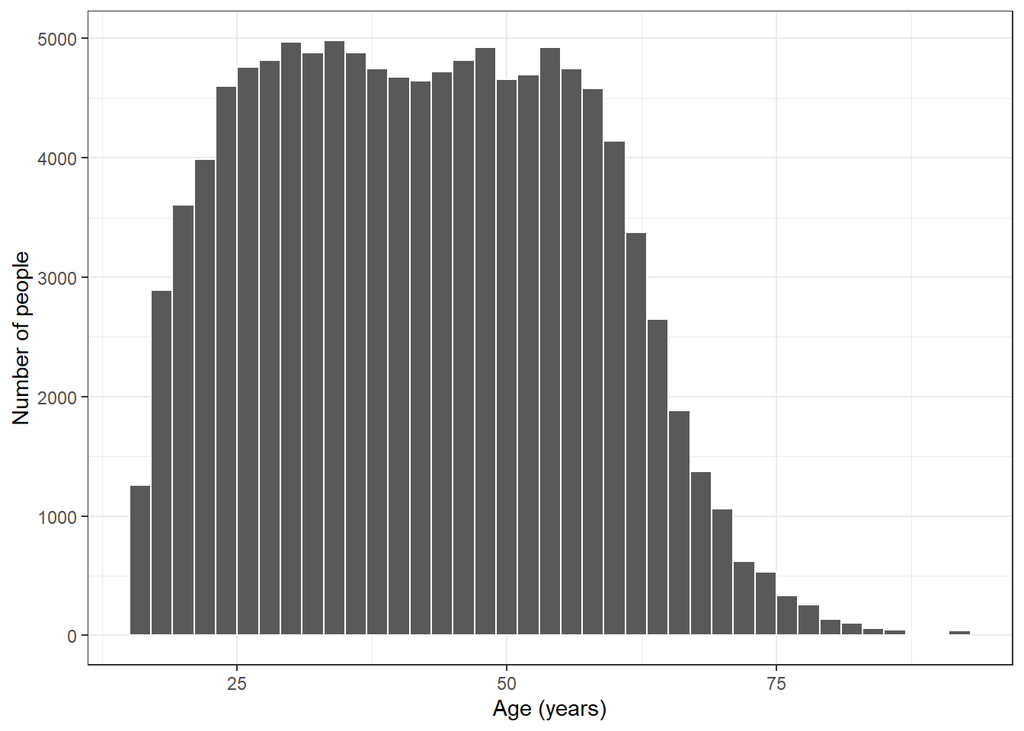

```r
ggplot(data, aes( x = Age)) +
  geom_histogram(color = "white", binwidth = 2) +
  theme_bw() +
  scale_x_continuous(name = "Age (years)") +
  scale_y_continuous(name = "Number of people")
```

Description:

The distribution of age in the sample looks normal and slightly right-skewed, with a higher frequency between the ages 31-54 and very few individuals over 75.

### Travel time

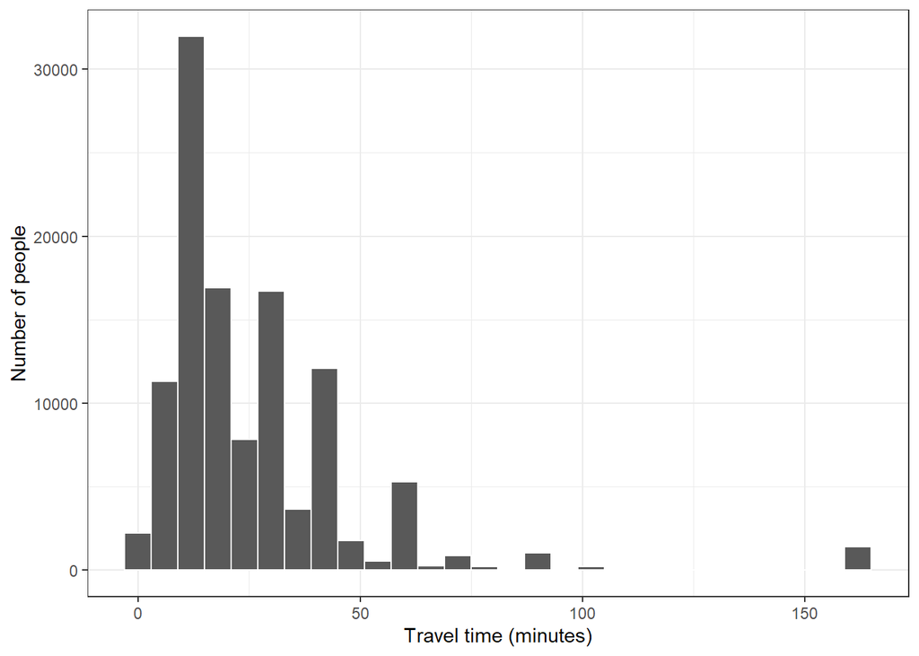

```r
ggplot(data, aes( x = Traveltime)) +
  geom_histogram(color = "white", binwidth = 6) +
  theme_bw() +
  scale_x_continuous(name = "Travel time (minutes)") +
  scale_y_continuous(name = "Number of people")
```

Description:

The distribution of the travel time variable is positively skewed (the mean is larger than the mode), and is mainly concentrated between 15 to 30 minutes.There is an extreme outlier over 150 minutes that probably responds to individuals commuting between cities.

For further analysis, I’m also interested in obtaining the percentage of people that travel less than 15 minutes:

```r
data %>%
mutate(
min15 = ifelse(Traveltime < 15, 1, 0)
) %>%
summarise(
tot_pop = n(),
tot_min15 = sum(min15)
) %>%
mutate(perc15 = tot_min15 / tot_pop) %>%

knitr::kable(caption = "Travel time less than 15 minutes")
```

Travel time less than 15 minutes

| tot_pop | tot_min15 | perc15 |
| --- | --- | --- |
| 114414 | 28471 | 0.2488419 |

### Income

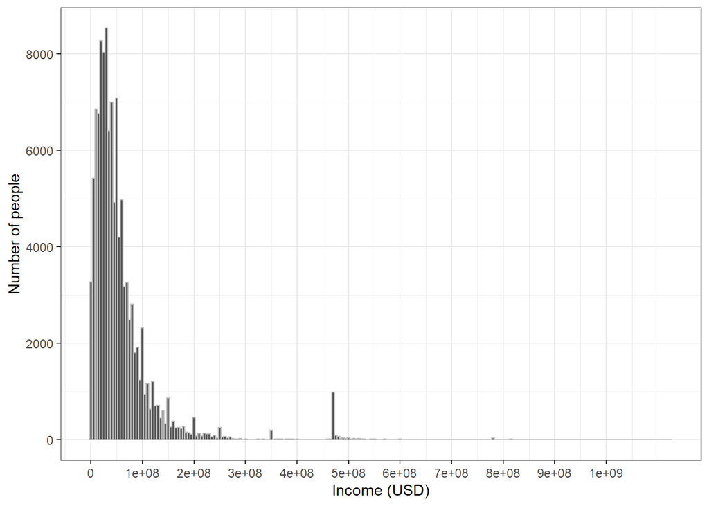

```r
ggplot(data, aes(x = Income)) +
  geom_histogram(color = "gray", binwidth = 5000) +
  theme_bw() +
  scale_x_continuous(name =
    "Income (USD)",
                     breaks = breaks <- seq(0, 1000000, by = 100000),
                     labels = paste(breaks*1000, sep = "")) +
  scale_y_continuous(name = "Number of people")
```

Description:

The income distribution is wide and also positively skewed, with the main values concentrated between USD 20,000 and 70,000.There are some high-value outliers that extend the tail of the graph and affect the mean of the variable.

## Distribution of Categorical Variables

For the categorical values I’ll browse through the labels of Means of Transportation and Educational Attainment.

### Means of Transportation

First, I’ll browse through the labels:

```r
unique (data$Meanstransp)
```

```
##  [1] "12" "02" "10" "01" "09" "05" "08" "03" "04" "07" "06"
```

I will select the following labels:

01= car, truck or van; 02= bus or trolleybus; 03= streetcar or trolleycar; 04= subway; 08= motorcycle; 09= bicycle; 10= walked.

I’ll do a test for each category of interest:

```r
Meanstransp01 <- t.test(data$Meanstransp == "01")
Meanstransp02 <- t.test(data$Meanstransp == "02")
Meanstransp03 <- t.test(data$Meanstransp == "03")
Meanstransp04 <- t.test(data$Meanstransp == "04")
Meanstransp08 <- t.test(data$Meanstransp == "08")
Meanstransp09 <- t.test(data$Meanstransp == "09")
Meanstransp10 <- t.test(data$Meanstransp == "10")
```

I’ll obtain the sample proportion and 95 percent confidence interval for each Means of Transportation:

```r
datatable <- tibble(`Label`= c("01", "02", "03", "04", "08", "09","10"),
`Sample proportion` = c(paste(prettyNum(Meanstransp01$estimate*100, digits = 3), "%"),
              paste(prettyNum(Meanstransp02$estimate*100, digits = 3),"%"),
              paste(prettyNum(Meanstransp03$estimate*100, digits = 3), "%"),
              paste(prettyNum(Meanstransp04$estimate*100, digits = 3), "%"),
              paste(prettyNum(Meanstransp08$estimate*100, digits = 3), "%"),
              paste(prettyNum(Meanstransp09$estimate*100, digits = 3), "%"),
              paste(prettyNum(Meanstransp10$estimate*100, digits = 3), "%")),
`95-percent confidence interval` =  c(paste(prettyNum(Meanstransp01$conf.int[1]*100,digits = 3), "% to ",
                                prettyNum(Meanstransp01$conf.int[2]*100,
                                          digits = 3), "%"),
                         paste(prettyNum(Meanstransp02$conf.int[1]*100,
                                          digits = 3), "% to ",
                                prettyNum(Meanstransp02$conf.int[2]*100,
                                          digits = 3), "%"),
                         paste(prettyNum(Meanstransp03$conf.int[1]*100,
                                          digits = 3), "% to ",
                                prettyNum(Meanstransp03$conf.int[2]*100,
                                          digits = 3), "%"),
                         paste(prettyNum(Meanstransp04$conf.int[1]*100,
                                          digits = 3), "% to ",
                                prettyNum(Meanstransp04$conf.int[2]*100,
                                          digits = 3), "%"),
                         paste(prettyNum(Meanstransp08$conf.int[1]*100,
                                          digits = 3), "% to ",
                                prettyNum(Meanstransp08$conf.int[2]*100,
                                          digits = 3), "%"),
                         paste(prettyNum(Meanstransp09$conf.int[1]*100,
                                          digits = 3), "% to ",
                                prettyNum(Meanstransp09$conf.int[2]*100,
                                          digits = 3), "%"),
                         paste(prettyNum(Meanstransp10$conf.int[1]*100,
                                          digits = 3), "% to ",
                                prettyNum(Meanstransp10$conf.int[2]*100,
                                          digits = 3), "%")))


knitr::kable(datatable, caption = "Means of Transportation")
```

Means of Transportation

| Label | Sample proportion | 95-percent confidence interval |
| --- | --- | --- |
| 01 | 95.6 % | 95.5 % to 95.7 % |
| 02 | 1.1 % | 1.04 % to 1.16 % |
| 03 | 0.0323 % | 0.0219 % to 0.0428 % |
| 04 | 0.0752 % | 0.0593 % to 0.091 % |
| 08 | 0.16 % | 0.137 % to 0.183 % |
| 09 | 0.268 % | 0.238 % to 0.298 % |
| 10 | 1.61 % | 1.53 % to 1.68 % |

### Educational Attainment

I repeated the process for the categorical variable Educational Attainment:

```r
unique(data$Edattain)
```

```
##  [1] "16" "20" "18" "19" "12" "17" "21" "22" "14" "06" "15" "13" "11" "23" "10"
## [16] "09" "24" "01" "03" "08" "07" "05" "04" "02"
```

I’ll select the following labels for my analysis:

01 = No schooling completed; 16 = Regular highschool diploma; 19 = 1 or more years of college credit; 21 = Bachelor’s degree; 22 = Master’s degree; 24 = Docorate degree.

I’ll do a test for each category of interest:

```r
Edattain01 <- t.test(data$Edattain == "01")
Edattain16 <- t.test(data$Edattain == "16")
Edattain19 <- t.test(data$Edattain == "19")
Edattain21 <- t.test(data$Edattain == "21")
Edattain22 <- t.test(data$Edattain == "22")
Edattain24 <- t.test(data$Edattain == "24")
```

I’ll obtain the sample proportion and 95 percent confidence interval of each category of interest:

```r
datatable_2 <- tibble(`Label`= c("01", "16", "19", "21", "22", "24"),
`Sample proportion` = c(paste(prettyNum(Edattain01$estimate*100, digits = 3), "%"),
              paste(prettyNum(Edattain16$estimate*100, digits = 3),"%"),
              paste(prettyNum(Edattain19$estimate*100, digits = 3), "%"),
              paste(prettyNum(Edattain21$estimate*100, digits = 3), "%"),
              paste(prettyNum(Edattain22$estimate*100, digits = 3), "%"),
              paste(prettyNum(Edattain24$estimate*100, digits = 3), "%")),
`95-percent confidence interval` =  c(paste(prettyNum(Edattain01$conf.int[1]*100,digits = 3), "% to ",
                                prettyNum(Edattain01$conf.int[2]*100,
                                          digits = 3), "%"),
                         paste(prettyNum(Edattain16$conf.int[1]*100,
                                          digits = 3), "% to ",
                                prettyNum(Edattain16$conf.int[2]*100,
                                          digits = 3), "%"),
                         paste(prettyNum(Edattain19$conf.int[1]*100,
                                          digits = 3), "% to ",
                                prettyNum(Edattain19$conf.int[2]*100,
                                          digits = 3), "%"),
                         paste(prettyNum(Edattain21$conf.int[1]*100,
                                          digits = 3), "% to ",
                                prettyNum(Edattain21$conf.int[2]*100,
                                          digits = 3), "%"),
                         paste(prettyNum(Edattain22$conf.int[1]*100,
                                          digits = 3), "% to ",
                                prettyNum(Edattain22$conf.int[2]*100,
                                          digits = 3), "%"),
                         paste(prettyNum(Edattain24$conf.int[1]*100,
                                          digits = 3), "% to ",
                                prettyNum(Edattain24$conf.int[2]*100,
                                          digits = 3), "%")))

knitr::kable(datatable_2, caption = "Educational Attainment")
```

Educational Attainment

| Label | Sample proportion | 95-percent confidence interval |
| --- | --- | --- |
| 01 | 1.42 % | 1.35 % to 1.48 % |
| 16 | 19.6 % | 19.4 % to 19.8 % |
| 19 | 15.8 % | 15.6 % to 16 % |
| 21 | 21.8 % | 21.5 % to 22 % |
| 22 | 8.75 % | 8.58 % to 8.91 % |
| 24 | 1.42 % | 1.36 % to 1.49 % |

Finally, I’ll save the dataset, the summary table of my continuous variables, and the tables of each categorical variable:

```r
write_csv(data, "data.csv")
write.csv(summary_table, "summary_table.csv")
write_csv(datatable, "datatable.csv")
write.csv(datatable_2, "datatable_2.csv")
```